# SparkJupyter

## ML Classification and the Higgs Boson Particle using Apache Spark MLib

The discovery of the Higgs Boson Pariticle was one of the significant developments in modern physics. The difficulty of this discovery was made more difficult by the unstable nature of the particle, decaying immediately into other particles. Evidence of the Higgs field and its properties has been extremely significant for many reasons. The importance of the Higgs boson is largely that it is able to be examined using existing knowledge and experimental technology, as a way to confirm and study the entire Higgs field theory.

In this notebook, we download and use data from the UCI Machine Learning and Intelligence Repository (https://archive.ics.uci.edu/ml/datasets/HIGGS) and we essentially classify the Higgs Boson Particle using a standard Machine Learning technique by following a tutorial from the SWAN examples. The dataset was used in this paper (https://arxiv.org/pdf/1402.4735.pdf). This notebook was inspired by the SWAN EXAMPLES (https://swan-gallery.web.cern.ch/), I plan on adding to it by comparing various ML techniques in the near future.

## Dataset Discription

The dataset was simulated using a Monte Carlo process. This is a binary classificatin problem where the goal is to train a classifier able to distinguish between a signal process, the production of new theoretical Higgs bosons, and a background process with identical decay products but distinct kinematic features.

Each row of this dataset contains 28 features plus the label:

21 low-level features which represent the basic measure made by the particle detector

- Momentum of the observed paricles
- Missing transverse momentum
- Jets and b-tagging information

7 high-level features computed from the low-level features that encode the knowledge of the different intermediate states of the two processes

Let's start by loading the data into a Spark dataframe and checking the fields.

```python
import findspark
findspark.init()

import pyspark # only run after findspark.init()
from pyspark.sql import SparkSession
spark = SparkSession.builder.getOrCreate()

df = spark.sql('''select 'spark' as hello ''')
df.show()
```

```
+-----+
|hello|
+-----+
|spark|
+-----+
```

```python
df = spark.read.format('csv').option('header', 'false').option('inferschema', 'true').load('HIGGS.csv')

total_events = df.count()
print('There are',total_events,'events')
```

```
There are 11000000 events
```

```python
df.printSchema()
```

```
root
 |-- _c0: double (nullable = true)
 |-- _c1: double (nullable = true)
 |-- _c2: double (nullable = true)
 |-- _c3: double (nullable = true)
 |-- _c4: double (nullable = true)
 |-- _c5: double (nullable = true)
 |-- _c6: double (nullable = true)
 |-- _c7: double (nullable = true)
 |-- _c8: double (nullable = true)
 |-- _c9: double (nullable = true)
 |-- _c10: double (nullable = true)
 |-- _c11: double (nullable = true)
 |-- _c12: double (nullable = true)
 |-- _c13: double (nullable = true)
 |-- _c14: double (nullable = true)
 |-- _c15: double (nullable = true)
 |-- _c16: double (nullable = true)
 |-- _c17: double (nullable = true)
 |-- _c18: double (nullable = true)
 |-- _c19: double (nullable = true)
 |-- _c20: double (nullable = true)
 |-- _c21: double (nullable = true)
 |-- _c22: double (nullable = true)
 |-- _c23: double (nullable = true)
 |-- _c24: double (nullable = true)
 |-- _c25: double (nullable = true)
 |-- _c26: double (nullable = true)
 |-- _c27: double (nullable = true)
 |-- _c28: double (nullable = true)
```

The feature we are trying to predict is _c0, this is the "signal" vs "background" feature. Let's check for balance in the data.

```python
df.groupBy('_c0').count().show()
```

```
+---+-------+
|_c0|  count|
+---+-------+
|0.0|5170877|
|1.0|5829123|
+---+-------+
```

We can see that the data is reasonably balanced, we now split into training and testing. Since the data is very large, and we can start by allocating 98% to the training set and 2% to the test set.

```python
train, test = df.randomSplit([0.98,0.02])
```

```python
print('Events for the training {}'.format(train.count()))
print('Events for the validation {}'.format(test.count()))
```

```
Events for the training 10779946
Events for the validation 220054
```

## Data Visualization

We can see that even with only 2% allocated to the test set, there are still over 200 thousand events in the test set. Let's take the label data from _c0 and plot it so that we can see their distributions accross one of the features which was shown to be significant in the original paper, the feature is m_bb in the paper and is feature _c26 in the data.

```python
import matplotlib.pyplot as plt
from pyspark.sql.functions import col
%matplotlib notebook

def compute_hist(data, feature, target='_c0', n_bins=100, x_lim=[0,3]):

    ## Fix the range
    data = data.where((col(feature)<=x_lim[1]) &
                      (col(feature)>=x_lim[0]))

    sgn = data.where(col(target)==1.0)
    bkg = data.where(col(target)==0.0)

    ## Compute the histograms
    bins_sgn, counts_sgn = sgn.select(feature).rdd.flatMap(lambda x: x).histogram(n_bins)
    bins_bkg, counts_bkg = bkg.select(feature).rdd.flatMap(lambda x: x).histogram(n_bins)

    return (bins_sgn, counts_sgn), (bins_bkg, counts_bkg)
```

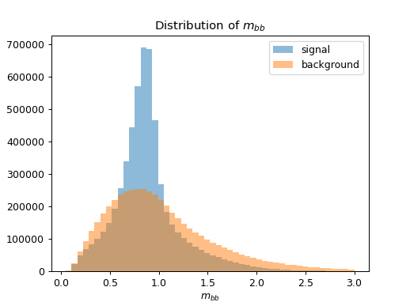

```python
%matplotlib notebook

## hist is a touple containing bins and counts foreach bin
hist_signal, hist_bkg = compute_hist(data=train, feature='_c26', target='_c0', n_bins=50, x_lim=[0,3])

f, ax = plt.subplots()
ax.hist(hist_signal[0][:-1], bins=hist_signal[0], weights=hist_signal[1], alpha=0.5, label='signal')
ax.hist(hist_bkg[0][:-1], bins=hist_bkg[0], weights=hist_bkg[1], alpha=0.5, label='background')
ax.set_xlabel('$m_{bb}$')
ax.set_ylabel('counts')
ax.set_title("Distribution of $m_{bb}$")
ax.legend()
plt.show()
```

## Feature Preperation

In this section we will prepare the input for the classifier. For the random forest we don't need to scale the features and encode the labels, we need only to create a Dense Vector containing the features.

```python
feature = train.columns
feature.remove('_c0')
feature
```

```
['_c1',
 '_c2',
 '_c3',
 '_c4',
 '_c5',
 '_c6',
 '_c7',
 '_c8',
 '_c9',
 '_c10',
 '_c11',
 '_c12',
 '_c13',
 '_c14',
 '_c15',
 '_c16',
 '_c17',
 '_c18',
 '_c19',
 '_c20',
 '_c21',
 '_c22',
 '_c23',
 '_c24',
 '_c25',
 '_c26',
 '_c27',
 '_c28']
```

To create a vector containing all the features we can use the VectorAssembler: we need to initiate it specifying the column containing the features and the output column that will contain the assembled vector. After this we can transform (create the assembled vectors) the tain and test dataframe.

```python
from pyspark.ml.feature import VectorAssembler

assembler = VectorAssembler(inputCols=feature, outputCol='features')
train = assembler.transform(train)
test = assembler.transform(test)
```

This is what a single row of the features column looks like

```python
train.select('features').take(1)
```

```
[Row(features=DenseVector([0.2747, -1.984, 0.7695, 1.4013, 1.496, 0.9565, 0.3327, -0.0321, 0.0, 0.7049, -0.8722, -1.0061, 2.2149, 0.6468, -0.353, -0.6304, 0.0, 1.0686, -0.2303, 1.3877, 3.102, 0.8953, 0.9776, 0.9931, 0.7897, 0.6978, 0.7528, 0.7791]))]
```

We will now use the seaborn plotting library in python to plot the correlation matrix of the features.

```python
from pyspark.ml.stat import Correlation

matrix = Correlation.corr(train.select('features'), 'features')
matrix_np = matrix.collect()[0]["pearson({})".format('features')].values
```

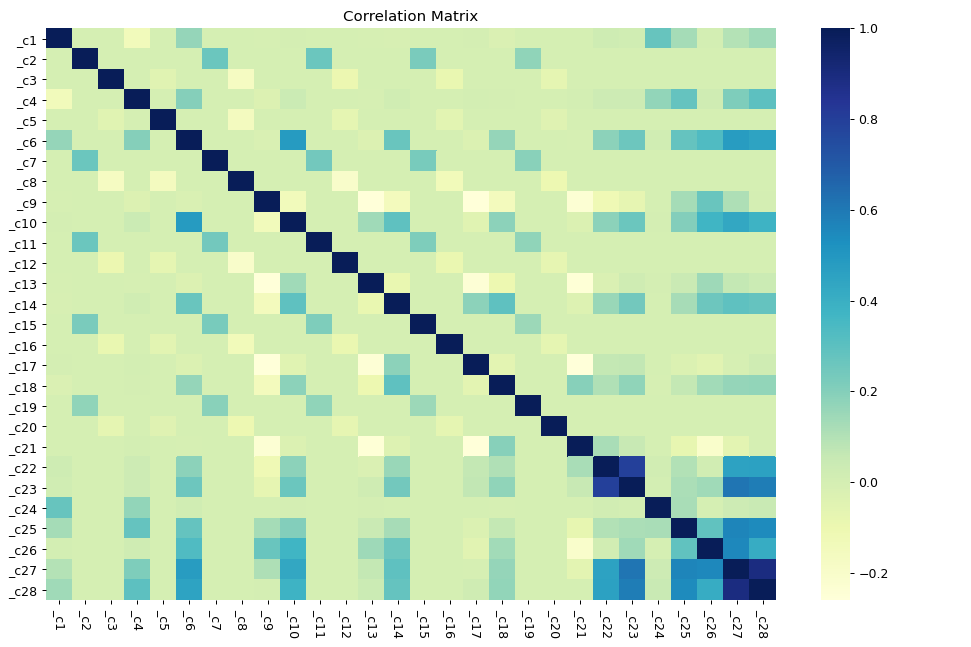

```python
import seaborn as sns

matrix_np = matrix_np.reshape(len(feature),len(feature))

fig, ax = plt.subplots(figsize=(12,8))
ax = sns.heatmap(matrix_np, cmap="YlGnBu")
ax.xaxis.set_ticklabels(feature, rotation=270)
ax.yaxis.set_ticklabels(feature, rotation=0)
ax.set_title("Correlation Matrix")
plt.tight_layout()
plt.show()
```

## Random Forest

Random forests are ensemble learning methos for classification and regression problems. In a Random forest we are combining a large number of independent trees trained over random and equally distributed subsets of the data obtained by sampling with replacement the original dataset.

As a starting point we will train a simple random forest with $50$ trees, without tuning the hyperparameters. We need to specify the columns containing the features vector and the label.

```python
from pyspark.ml.classification import RandomForestClassifier

rf = RandomForestClassifier(labelCol='_c0', featuresCol='features', numTrees=50)
```

```python
rf = rf.fit(train)
```

We can now use our trained model to predict the test instances

```python
pred = rf.transform(test)
```

```python
pred.select('_c0', 'prediction', 'probability').show(5)
```

```
+---+----------+--------------------+
|_c0|prediction|         probability|
+---+----------+--------------------+
|0.0|       0.0|[0.55366503742950...|
|0.0|       1.0|[0.32798934521693...|
|0.0|       0.0|[0.54164341113612...|
|0.0|       1.0|[0.45571628124762...|
|0.0|       0.0|[0.50017084152561...|
+---+----------+--------------------+
only showing top 5 rows
```

Since the test dataset is small we can convert it into a pandas dataframe. This allows us to use sklearn and matplotlib.

```python
pred_pd = pred.select(['_c0', 'prediction', 'probability']).toPandas()
```

```python
pred_pd.head()
```

|  | _c0 | prediction | probability |
| --- | --- | --- | --- |
| 0 | 0.0 | 0.0 | [0.5536650374295082, 0.44633496257049177] |
| 1 | 0.0 | 1.0 | [0.32798934521693207, 0.672010654783068] |
| 2 | 0.0 | 0.0 | [0.5416434111361269, 0.45835658886387315] |
| 3 | 0.0 | 1.0 | [0.45571628124762303, 0.5442837187523769] |
| 4 | 0.0 | 0.0 | [0.5001708415256119, 0.499829158474388] |

```python
import numpy as np
pred_pd['probability'] = pred_pd['probability'].map(lambda x: list(x))
pred_pd['encoded_label'] = pred_pd['_c0'].map(lambda x: np.eye(2)[int(x)])
```

```python
y_pred = np.array(pred_pd['probability'].tolist())
y_true = np.array(pred_pd['encoded_label'].tolist())
```

```python
from sklearn.metrics import auc, roc_curve

fpr, tpr, threshold = roc_curve(y_score=y_pred[:,0], y_true=y_true[:,0])
auc = auc(fpr, tpr)

print('AUC: {:.3f}'.format(auc))
```

```
AUC: 0.741
```

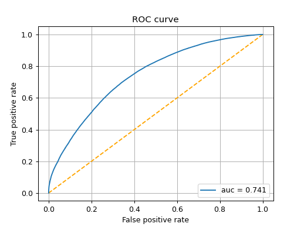

```python
plt.figure()
plt.plot([0,1], [0,1], 'k--', color='orange')
plt.plot(fpr, tpr, label='auc = {:.3f}'.format(auc))
plt.xlabel('False positive rate')
plt.ylabel('True positive rate')
plt.title('ROC curve')
plt.legend(loc='lower right')
plt.grid()
plt.show()
```

This was a fun tutorial which I followed from SWAN examples using the link provided at the top of the page. It was a good introduction to Apache Spark MLib and PySpark, it was also a good introduction to using Spark in a Jupyter Notebook.

The performance here was decent, however it can be improved by doing a number of things, including using a cross validationn process and by tuning the hyperparameters such as the numnber of trees and the depth of each tree.